# Working with Data

*(C) Harm Schuett 2018, schuett@bwl.lmu.de, see LICENSE file for details*

## The Current Working Directory

For most data applications, you want to load and save files. To do that it is important to know where your application’s current working directory is. It is the reference point for all your load and save operations. You can check and set the location of the working directory with `getwd()` and `setwd()`:

```r
getwd()
```

```
## [1] "C:/Users/schuett/Dropbox/GitRepos/EmpAccDataTut/Session1"
```

```r
# Note I commented these out here because working inside an RNotebook
# I would not normally change the working directory. But for scripts
# This is something you should normally set.
# setwd("../../EmpAccDataTut/")
getwd()
```

```
## [1] "C:/Users/schuett/Dropbox/GitRepos/EmpAccDataTut/Session1"
```

You can use ``../` to go one folder backwards from where your current wd is looking at. so the above `../../EmpAccDataTut/` means “go two folders back and then jump into the EmpAccDataTut” folder.

## Loading Data

There are many ways of loading data in RStudio, but the best way of doing so in a replicable way is by calling a command from within your R script.

Let’s download some data from the net and then load it:

```r
download.file("https://www.census.gov/2010census/csv/pop_change.csv",
              "../Data/pop_change.csv")
```

I prefer to put a “df_” before data.frame objects, so that all of them are grouped together in the Enironment pane. The most commonly used file format for small to medium data sets is .csv (comma searated variables). It is a simple text file. You can load it via the read.csv function that returns a data.frame as output:

```r
df_pop_change = read.csv("../Data/pop_change.csv", skip=2)
str(df_pop_change)
```

```
## 'data.frame':    57 obs. of  23 variables:
##  $ STATE_OR_REGION : Factor w/ 57 levels "Alabama","Alaska",..: 49 37 24 44 54 1 2 3 4 5 ...
##  $ X1910_POPULATION: int  92228531 25868573 29888542 29389330 7082086 2138093 64356 204354 1574449 2377549 ...
##  $ X1920_POPULATION: int  106021568 29662053 34019792 33125803 9213920 2348174 55036 334162 1752204 3426861 ...
##  $ X1930_POPULATION: int  123202660 34427091 38594100 37857633 12323836 2646248 59278 435573 1854482 5677251 ...
##  $ X1940_POPULATION: int  132165129 35976777 40143332 41665901 14379119 2832961 72524 499261 1949387 6907387 ...
##  $ X1950_POPULATION: int  151325798 39477986 44460762 47197088 20189962 3061743 128643 749587 1909511 10586223 ...
##  $ X1960_POPULATION: int  179323175 44677819 51619139 54973113 28053104 3266740 226167 1302161 1786272 15717204 ...
##  $ X1970_POPULATION: int  203211926 49040703 56571663 62795367 34804193 3444165 300382 1770900 1923295 19953134 ...
##  $ X1980_POPULATION: int  226545805 49135283 58865670 75372362 43172490 3893888 401851 2718215 2286435 23667902 ...
##  $ X1990_POPULATION: int  248709873 50809229 59668632 85445930 52786082 4040587 550043 3665228 2350725 29760021 ...
##  $ X2000_POPULATION: int  281421906 53594378 64392776 100236820 63197932 4447100 626932 5130632 2673400 33871648 ...
##  $ X2010_POPULATION: int  308745538 55317240 66927001 114555744 71945553 4779736 710231 6392017 2915918 37253956 ...
##  $ X1910_CHANGE    : num  21 22.9 13.5 19.8 64.4 16.9 1.2 66.2 20 60.1 ...
##  $ X1920_CHANGE    : num  15 14.7 13.8 12.7 30.1 9.8 -14.5 63.5 11.3 44.1 ...
##  $ X1930_CHANGE    : num  16.2 16.1 13.4 14.3 33.8 12.7 7.7 30.3 5.8 65.7 ...
##  $ X1940_CHANGE    : num  7.3 4.5 4 10.1 16.7 7.1 22.3 14.6 5.1 21.7 ...
##  $ X1950_CHANGE    : num  14.5 9.7 10.8 13.3 40.4 8.1 77.4 50.1 -2 53.3 ...
##  $ X1960_CHANGE    : num  18.5 13.2 16.1 16.5 38.9 6.7 75.8 73.7 -6.5 48.5 ...
##  $ X1970_CHANGE    : num  13.3 9.8 9.6 14.2 24.1 5.4 32.8 36 7.7 27 ...
##  $ X1980_CHANGE    : num  11.5 0.2 4.1 20 24 13.1 33.8 53.5 18.9 18.6 ...
##  $ X1990_CHANGE    : num  9.8 3.4 1.4 13.4 22.3 3.8 36.9 34.8 2.8 25.7 ...
##  $ X2000_CHANGE    : num  13.2 5.5 7.9 17.3 19.7 10.1 14 40 13.7 13.8 ...
##  $ X2010_CHANGE    : num  9.7 3.2 3.9 14.3 13.8 7.5 13.3 24.6 9.1 10 ...
```

```r
head(df_pop_change, 6)  # print first 6 rows
```

|  | STATE_OR_REGION | X1910_POPULATION | X1920_POPULATION | X1930_POPULATION | X1940_POPULATION | X1950_POPULATION | X1960_POPULATION | X1970_POPULATION | X1980_POPULATION | X1990_POPULATION | X2000_POPULATION | X2010_POPULATION | X1910_CHANGE | X1920_CHANGE | X1930_CHANGE | X1940_CHANGE | X1950_CHANGE | X1960_CHANGE | X1970_CHANGE | X1980_CHANGE | X1990_CHANGE | X2000_CHANGE | X2010_CHANGE |
| --- | --- | --- | --- | --- | --- | --- | --- | --- | --- | --- | --- | --- | --- | --- | --- | --- | --- | --- | --- | --- | --- | --- | --- |
| 1 | United States | 92228531 | 106021568 | 123202660 | 132165129 | 151325798 | 179323175 | 203211926 | 226545805 | 248709873 | 281421906 | 308745538 | 21.0 | 15.0 | 16.2 | 7.3 | 14.5 | 18.5 | 13.3 | 11.5 | 9.8 | 13.2 | 9.7 |
| 2 | Northeast | 25868573 | 29662053 | 34427091 | 35976777 | 39477986 | 44677819 | 49040703 | 49135283 | 50809229 | 53594378 | 55317240 | 22.9 | 14.7 | 16.1 | 4.5 | 9.7 | 13.2 | 9.8 | 0.2 | 3.4 | 5.5 | 3.2 |
| 3 | Midwest | 29888542 | 34019792 | 38594100 | 40143332 | 44460762 | 51619139 | 56571663 | 58865670 | 59668632 | 64392776 | 66927001 | 13.5 | 13.8 | 13.4 | 4.0 | 10.8 | 16.1 | 9.6 | 4.1 | 1.4 | 7.9 | 3.9 |
| 4 | South | 29389330 | 33125803 | 37857633 | 41665901 | 47197088 | 54973113 | 62795367 | 75372362 | 85445930 | 100236820 | 114555744 | 19.8 | 12.7 | 14.3 | 10.1 | 13.3 | 16.5 | 14.2 | 20.0 | 13.4 | 17.3 | 14.3 |
| 5 | West | 7082086 | 9213920 | 12323836 | 14379119 | 20189962 | 28053104 | 34804193 | 43172490 | 52786082 | 63197932 | 71945553 | 64.4 | 30.1 | 33.8 | 16.7 | 40.4 | 38.9 | 24.1 | 24.0 | 22.3 | 19.7 | 13.8 |
| 6 | Alabama | 2138093 | 2348174 | 2646248 | 2832961 | 3061743 | 3266740 | 3444165 | 3893888 | 4040587 | 4447100 | 4779736 | 16.9 | 9.8 | 12.7 | 7.1 | 8.1 | 6.7 | 5.4 | 13.1 | 3.8 | 10.1 | 7.5 |

## Data Wrangling

### Installing packages

Now this is not a very useful data representation for actually analyzing data. And that is common. Usually, your data analysis tasks will demand a considerable amount of data wrangling before you can actually work with it. This one is a small example to get your feet wet.

We will use the dplyr package quite heavily now. Many of these things you can do in base R without the package too, but it is simpler and faster in dplyr so why bother.

dplyr is part of the tidyverse collection of packages. We will need to install them first using the `install.packages()` function

```r
# install.packages("dplyr")
# This will install a bunch of packages, not just dplyr.
# But we will used most of them anyway.
# install.packages("tidyverse")
```

We load packages using the library() function.

```r
library(dplyr)    # data wrangling
```

```r
library(tidyr)    # transposing data
library(ggplot2)  # plotting library
```

You will see some warnings. dpylr masks some already existing functions like the `filter()` function.

### Selecting and Filtering

First things first, we don’t want the changes columns and we want the four USA parts. To get the first, we need to `dplyr::select()` columns and for the second we need to `dplyr::filter()` rows.

```r
unique(df_pop_change$STATE_OR_REGION)
```

```
##  [1] United States        Northeast            Midwest
##  [4] South                West                 Alabama
##  [7] Alaska               Arizona              Arkansas
## [10] California           Colorado             Connecticut
## [13] Delaware             District of Columbia Florida
## [16] Georgia              Hawaii               Idaho
## [19] Illinois             Indiana              Iowa
## [22] Kansas               Kentucky             Louisiana
## [25] Maine                Maryland             Massachusetts
## [28] Michigan             Minnesota            Mississippi
## [31] Missouri             Montana              Nebraska
## [34] Nevada               New Hampshire        New Jersey
## [37] New Mexico           New York             North Carolina
## [40] North Dakota         Ohio                 Oklahoma
## [43] Oregon               Pennsylvania         Rhode Island
## [46] South Carolina       South Dakota         Tennessee
## [49] Texas                Utah                 Vermont
## [52] Virginia             Washington           West Virginia
## [55] Wisconsin            Wyoming              Puerto Rico
## 57 Levels: Alabama Alaska Arizona Arkansas California ... Wyoming
```

```r
regions <- c("Northeast", "Midwest", "South", "West")

df_pops <- df_pop_change %>%
  select(STATE_OR_REGION, X1910_POPULATION:X2010_POPULATION) %>%
  filter(STATE_OR_REGION %in% regions)
df_pops
```

| STATE_OR_REGION | X1910_POPULATION | X1920_POPULATION | X1930_POPULATION | X1940_POPULATION | X1950_POPULATION | X1960_POPULATION | X1970_POPULATION | X1980_POPULATION | X1990_POPULATION | X2000_POPULATION | X2010_POPULATION |
| --- | --- | --- | --- | --- | --- | --- | --- | --- | --- | --- | --- |
| Northeast | 25868573 | 29662053 | 34427091 | 35976777 | 39477986 | 44677819 | 49040703 | 49135283 | 50809229 | 53594378 | 55317240 |
| Midwest | 29888542 | 34019792 | 38594100 | 40143332 | 44460762 | 51619139 | 56571663 | 58865670 | 59668632 | 64392776 | 66927001 |
| South | 29389330 | 33125803 | 37857633 | 41665901 | 47197088 | 54973113 | 62795367 | 75372362 | 85445930 | 100236820 | 114555744 |
| West | 7082086 | 9213920 | 12323836 | 14379119 | 20189962 | 28053104 | 34804193 | 43172490 | 52786082 | 63197932 | 71945553 |

### Transpose operations

To be useful for many applications, we’d like to have this in what’s called a *long format*. The tidyr package has a lot of data transposing functions. For example, note that we have one column for different decades. Instead, we’d like to have one column for population with each row bein a decade. One additional complication is that we want this for eacch region. The `'tidyr::gather()` function does just that:

```r
df_pops_long <- df_pops %>%
  gather(key="period", value="population", -STATE_OR_REGION)
df_pops_long
```

| STATE_OR_REGION | period | population |
| --- | --- | --- |
| Northeast | X1910_POPULATION | 25868573 |
| Midwest | X1910_POPULATION | 29888542 |
| South | X1910_POPULATION | 29389330 |
| West | X1910_POPULATION | 7082086 |
| Northeast | X1920_POPULATION | 29662053 |
| Midwest | X1920_POPULATION | 34019792 |
| South | X1920_POPULATION | 33125803 |
| West | X1920_POPULATION | 9213920 |
| Northeast | X1930_POPULATION | 34427091 |
| Midwest | X1930_POPULATION | 38594100 |

[output cut: 34 more lines]

Alternatively, we could have a column for each region. Then we need to go to wide format again, but using the STATE_OR_REGIONcolumn instead. This can be done using `tidyr::spread()`

```r
df_pops_wide <- df_pops_long %>%
  spread(key=STATE_OR_REGION, value=population)
df_pops_wide
```

| period | Midwest | Northeast | South | West |
| --- | --- | --- | --- | --- |
| X1910_POPULATION | 29888542 | 25868573 | 29389330 | 7082086 |
| X1920_POPULATION | 34019792 | 29662053 | 33125803 | 9213920 |
| X1930_POPULATION | 38594100 | 34427091 | 37857633 | 12323836 |
| X1940_POPULATION | 40143332 | 35976777 | 41665901 | 14379119 |
| X1950_POPULATION | 44460762 | 39477986 | 47197088 | 20189962 |
| X1960_POPULATION | 51619139 | 44677819 | 54973113 | 28053104 |
| X1970_POPULATION | 56571663 | 49040703 | 62795367 | 34804193 |
| X1980_POPULATION | 58865670 | 49135283 | 75372362 | 43172490 |
| X1990_POPULATION | 59668632 | 50809229 | 85445930 | 52786082 |
| X2000_POPULATION | 64392776 | 53594378 | 100236820 | 63197932 |

[output cut: 1 more lines]

### Transforming variables

```r
# this is how you would create a new df with a new variable
# in base R. Nothing unexpected and clear to read.
df_pops_long2 <- df_pops_long
df_pops_long2$decade <-  as.integer( substr(df_pops_long2$period, 2, 5) )
# This is how you could do it using dplyr mutate:
df_pops_long2 <- df_pops_long %>%
  mutate(decade = as.integer( substr(period, 2, 5) ))
```

### Pipes

In fact, we could have chained everything into one long chain using the magrittr pipe operator `%>%`:

```r
df_final_long <- df_pop_change %>%
  select(STATE_OR_REGION, X1910_POPULATION:X2010_POPULATION) %>%
  filter(STATE_OR_REGION %in% regions) %>%
  gather(key="period", value="population", -STATE_OR_REGION) %>%
  mutate(decade = as.integer( substr(period, 2, 5) ),
         population = population / 1000000) %>%
  select(-period) %>%
  rename(region = STATE_OR_REGION)
df_final_long
```

| region | population | decade |
| --- | --- | --- |
| Northeast | 25.868573 | 1910 |
| Midwest | 29.888542 | 1910 |
| South | 29.389330 | 1910 |
| West | 7.082086 | 1910 |
| Northeast | 29.662053 | 1920 |
| Midwest | 34.019792 | 1920 |
| South | 33.125803 | 1920 |
| West | 9.213920 | 1920 |
| Northeast | 34.427091 | 1930 |
| Midwest | 38.594100 | 1930 |

[output cut: 34 more lines]

## Plotting

R has two plotting systems. The base R version and the ggplot library. Both are really good and powerful (I have a faible for Python’s matplotlib though). You can do great things with both. But they work differently. At the beginning, it makes sense to focus on one. We will focus on ggplot first.

This is base R:

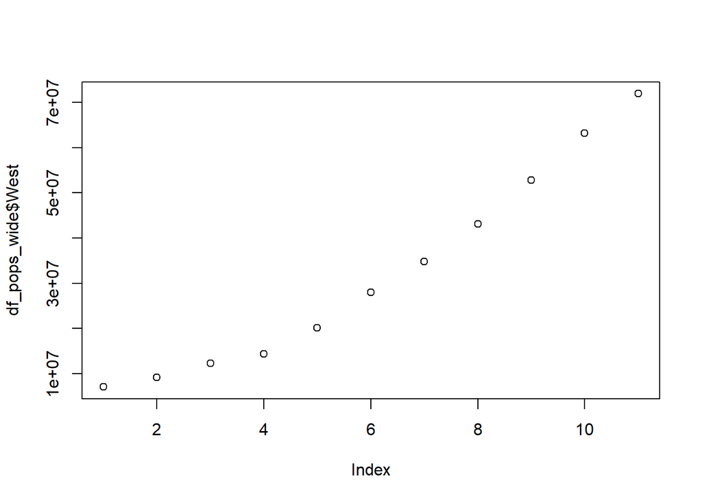

This is ggplot:

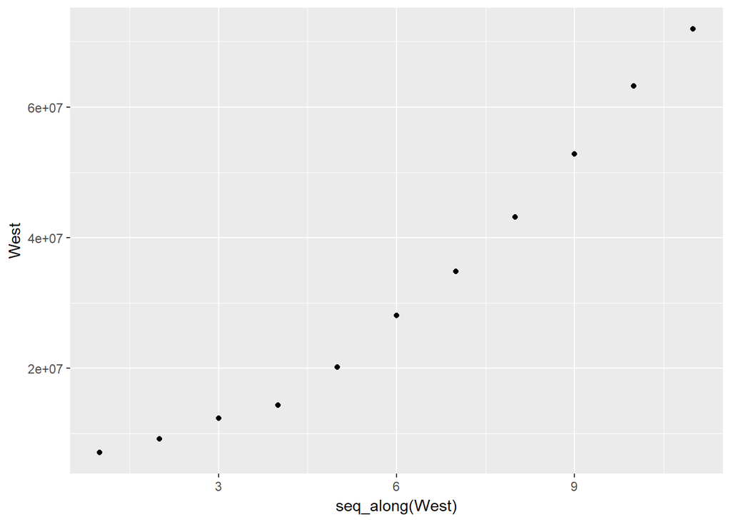

```r
ggplot(data=df_pops_wide, aes(x=seq_along(West), y=West)) +
  geom_point()
```

ggplto makes it a bit easier to create print/production ready plots, which is why we focus on that first.

For example:

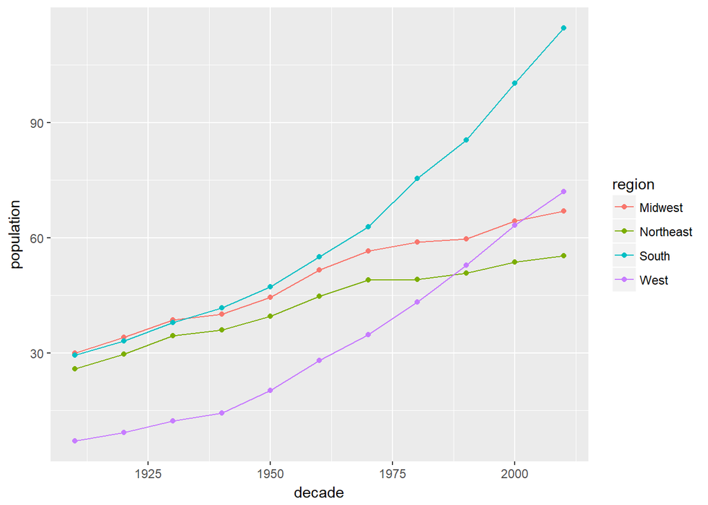

```r
plt_raw <- ggplot(data=df_final_long,  # creates canvas
       # declares what determines x- and y-variables and a grouping for subsets
       aes(x=decade, y=population, group=region)) +
  geom_line(aes(color=region)) +  # draws lines on canvas
  geom_point(aes(color=region))   # draws points
plt_raw
```

Note above that we used `+` instead of `%>%` because ggplot is an older package. You can pimp these plots in thousands of ways:

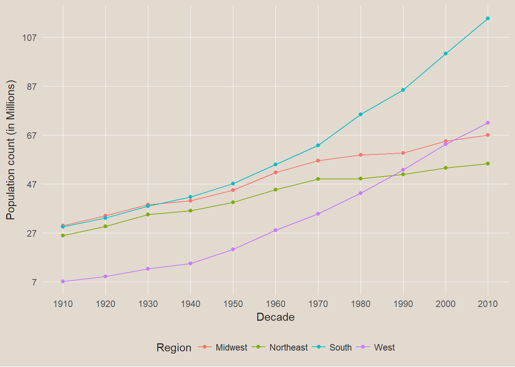

```r
min_pop <- floor( min(df_final_long$population) )
max_pop <- round( max(df_final_long$population) )
plt_raw +
  scale_x_continuous(breaks=seq(1910, 2010, 10)) +
  scale_y_continuous(breaks=seq(min_pop, max_pop, 20)) +
  labs(x="Decade",
       y="Population count (in Millions)",
       color="Region")+
  theme_minimal() +
  theme(panel.grid.minor = element_blank(),
        legend.position = "bottom",
        panel.grid.major = element_line(colour = "white", size = 0.2, linetype="solid"),
        text = element_text(color="#2D2D2D"),
        plot.background = element_rect(fill="#e2d9cf", colour=NA)
        )
```

Btw, maybe take a look and compare the graphs from before to this one. THink about how much more informative this one is.